# Client Report -How good is it, really?

- Show All Code
- Hide All Code

Unit 4 Task 2

Author

Zach McLaughlin

```python
import pandas as pd
import numpy as np
from lets_plot import *
# add the additional libraries you need to import for ML here

LetsPlot.setup_html(isolated_frame=True)

from sklearn.model_selection import train_test_split

from sklearn.ensemble import RandomForestClassifier

from sklearn.metrics import classification_report
```

```python
df = pd.read_csv('https://raw.githubusercontent.com/byuidatascience/data4dwellings/master/data-raw/dwellings_ml/dwellings_ml.csv')
df

X = df.drop(columns=['before1980', 'yrbuilt', 'parcel'])
y = df.before1980

X_train, X_test, y_train, y_test = train_test_split(X, y, test_size=0.2, random_state=1)

model = RandomForestClassifier()
model.fit(X_train, y_train)

pred = model.predict(X_test)
```

## QUESTION 1

**Describe the quality of your classification model using 2-3 different evaluation metrics.** You also need to explain how to interpret each of the evaluation metrics you use.

Below we can see the accuracy, precision, recall, as well as F1 score of our model. Accuracy is how often the predictions were correct, precision is how many of the predicted “yes” were actually a “yes”, and recall is, of all the homes built before 1980, how many were correctly predicted. F1 score is a combination of precision and recall, making it a great option in many cases to see the true performance of your model.

```python
from sklearn.metrics import accuracy_score, precision_score, recall_score, f1_score

accuracy = accuracy_score(y_test, pred)
precision = precision_score(y_test, pred)
recall = recall_score(y_test, pred)
f1 = f1_score(y_test, pred)

print(f"Accuracy: {accuracy:.3f}")
print(f"Precision: {precision:.3f}")
print(f"Recall: {recall:.3f}")
print(f"F1 Score: {f1:.3f}")
```

```
Accuracy: 0.926
Precision: 0.939
Recall: 0.943
F1 Score: 0.941
```

## QUESTION 2

**Justify your classification model by discussing the most important features selected by your model.** This discussion should include a feature importance chart and a description of the features.

In the chart below, you can see a chart that displays the top 10 most important features in order from most to least. Livearea is the number one feature used to calculate whether a house is built before 1980 or not.

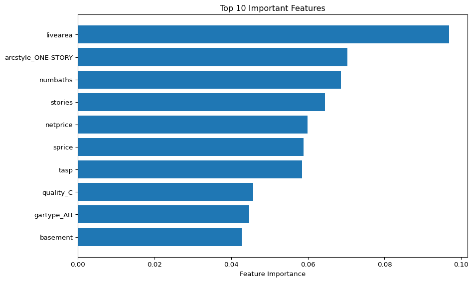

```python
import matplotlib.pyplot as plt

importances = model.feature_importances_
features = X.columns
feat_df = pd.DataFrame({'Feature': features, 'Importance': importances})
feat_df = feat_df.sort_values('Importance', ascending=False)

# Plot
plt.figure(figsize=(10, 6))
plt.barh(feat_df['Feature'][:10][::-1], feat_df['Importance'][:10][::-1])
plt.xlabel("Feature Importance")
plt.title("Top 10 Important Features")
plt.tight_layout()
plt.show()
```

Back to top